# Crash Course on Python (via IPython) and Beginner Visualization and Numerical Computation

## Jon Woodring Los Alamos National Laboratory

### The Ohio State University October 10, 2014

# To follow along in IPython

## Step One

Download this IPython notebook at Github:

https://github.com/DataScienceAtScale/python-at-osu-oct-10 *then click on the link in the README*

or get it directly via

https://raw.githubusercontent.com/DataScienceAtScale/python-at-osu-oct-10/master/Python_at_OSU_Oct_10.ipynb

# Optionally follow along without IPython

Use nbviewer to see the static version of the notebook in the web:

http://nbviewer.ipython.org/github/DataScienceAtScale/python-at-osu-oct-10/blob/master/Python_at_OSU_Oct_10.ipynb

**You can stop here if you are viewing the static web version.**

## Step Two

Download and install Anaconda Python from Continuum Analytics. Use Python 3.4, as there isn't a good reason to use 2.7 as a beginner:

http://continuum.io/downloads#py34

### Optional Install

There are other Python options as well, such as *Python(X,Y)*, *WinPython*, *MiniConda* version of *Anaconda*, or using *pip* to install packages with an existing installed version of *Python*.

If you are using any of these versions, also make sure that you install:

- IPython Notebook (will also get IPython command line as a dependency)
- SciPy (will also get NumPy as a dependency)
- Pandas
- Matplotlib

## Step Three

Launch IPython Notebook in the directory where *Python_at_OSU_Oct_10.ipynb* is located.

This will open a webpage for the IPython Notebook interface. From the terminal (for example if you downloaded the notebook in Downloads):

```
$ cd ~/Downloads
$ ls Python_at_OSU_Oct_10.ipynb
Python_at_OSU_Oct_10.ipynb
$ ipython notebook
```

Alternatively, launch IPython Notebook and copy the notebook file into the directory where ipython was launched:

```
$ cp ~/Downloads/Python_at_OSU_Oct_10.ipynb .
$ ipython notebook
```

### What it looks like if you successfully launched IPython Notebook

[figure not shown]

## Step Four

Open the notebook (*Python_at_OSU_Oct_10.ipynb*) from the web interface that was opened in your browser:

[figure not shown]

# 3 Reasons Why I like Python

## Rather than telling you why you should like it, I'm going to tell you why I like it.

# #1 My 881 project written in Python (taken with with Professor Dey) still works

## I haven't touched it in 10+ years and I just ran it last Friday to see if it worked

[figure not shown]

# Yep! Still works!

## I have written volume renderers, high-dimensional visualizations, analysis tools, web servers, benchmarks, parallel processing, data manipulation, demonstrations, etc. all in Python

# #2 import antigravity

[figure not shown]

## and a million other things: numerics, graphics, web, GPU, distributed, GUIs, databases, analytics, etc.

### The things that Python isn't good at (yet): compilation and shared-memory threading

# #3 IPython + Matplotlib + Numpy + SciPy + SQLite = Amazing

## Everything in this tutorial was created with these Python tools

## A mention goes to Cython, which makes it really easy to call C code directly from Python

# Plus, the language is fun. It is so easy to do anything

```python
# So let's get into it

print('Hello world!')
```

```
Hello world!
```

# An Interactive Demo of IPython Notebook

# To execute IPython Cells, press *Ctrl-Enter* or the play button on the toolbar

# Python

- A dynamically typed language (methods and functions are checked at run-time)
- Whitespace is meaningful for blocks (no semi-colons/terminators)
- Syntax is C-like (Algol-like)
- Built-in immutable data types: integers, floating point, strings, tuples, etc.
- Built-in mutable data structures: lists, associative maps (dicts/hashes), sets, etc.
- Automatic memory management (reference counting)
- Exception handling (try/except)
- Functions are first-class (they can be passed around as arguments)
- Object-oriented paradigms can be used (classes)
- A huge standard library
- CPython is the standard implementation, which is interpreted (there are efforts to make JIT compilers, such as *pypy* and *Numba*)
- Bind to C for speed (Python is an excellent "glue" language)

```python
# assignment & print function

x = 0 # you don't have to declare x first
print(x) # calling built-in function

y = 1.0 # just assign a literal to a name
print(y) # calling looks just like C and other Algol-languages

z = 'foo' # a string with quotes
print(z) # no semi-colons or other terminators

w = "bar" # another string with double quotes (either works)
print(w)
```

```
0
1.0
foo
bar
```

```python
# more assignment & expressions

x = 4
y = 2
z = 3
r = 'one'
s = 'two'
t = 'three'
f = 1.0

a = x * y + z # expressions look like most other infix notation
print(a)

print(r + s + t) # concatenating strings & expression
                 # in a function argument

b, c, d = x + f, 4 * f, y ** z # multiple assigments on one line
print(b, c, d) # adding numeric types casts integer to float

print(x + r) # but this doesn't work
             # (won't cast a numeric to a string, unlike Javascript)
```

```
11
onetwothree
5.0 4.0 8
```

```
---------------------------------------------------------------------------
TypeError                                 Traceback (most recent call last)
<ipython-input-3-5f6b17d95c9a> in <module>()
     18 print(b, c, d) # adding numeric types casts integer to float
     19
---> 20 print(x + r) # but this doesn't work
     21              # (won't cast a numeric to a string, unlike Javascript)
     22

TypeError: unsupported operand type(s) for +: 'int' and 'str'
```

```python
# conversions and types

x = '1.01'

print(x, type(x)) # type is another built-in function
x = float(x) # x is now a float
print(x, type(x)) # print can take multiple arguments
x = int(x)
print(x, type(x)) # now it's an integer
x = str(x)
print(x, type(x))
```

```
1.01 <class 'str'>
1.01 <class 'float'>
1 <class 'int'>
1 <class 'str'>
```

```python
# lists (vectors, really)

x = [1, 2, 3, 4, 5] # a list of integers
print(x)

y = [1.0, 2.0, 3.0, 4.0, 5.0] # a list of floating point
print(y)

z = ['a', 'b', 'c', 'd', 'e'] # a list of strings
print(z)

w = [1, 'two', 3.0, "four", print, 'last'] # can we mix them?
print(w) # yes, we can
```

```
[1, 2, 3, 4, 5]
[1.0, 2.0, 3.0, 4.0, 5.0]
['a', 'b', 'c', 'd', 'e']
[1, 'two', 3.0, 'four', <built-in function print>, 'last']
```

```python
# accessing lists

w = [1, 'two', 3.0, "four", print, 'last']
print(w)

# accessing is array notation
# a Python list is like a "vector" in C++
# random access, reverse is constant time, etc.
print(w[0]) # first item
print(w[1]) # second item
print(w[len(w)-1]) # last item, len is a built-in function
print(w[-1]) # this is the last item, too
print(w[-2]) # second to last

w[0] = w[-1] # let's copy the last item to the first
print(w[0])
```

```
[1, 'two', 3.0, 'four', <built-in function print>, 'last']
1
two
last
last
<built-in function print>
last
```

```python
# list slices

w = [1, 2, 3, 4, 5]

# slices - like Matlab and Fortran
print(w[2:]) # everything from 2 onwards
print(w[:2]) # right hand index is exclusive
print(w[:2] + w[2:]) # list concatenation

# you can do subranges
print(w[1:3])

# you can do skips
print(w[::2])

# even in reverse
print(w[::-1])

# you can combine them all together
print(w[3:0:-2]) # notice I had to do 3 to 0 by -2 to go in reverse
```

```
[3, 4, 5]
[1, 2]
[1, 2, 3, 4, 5]
[2, 3]
[1, 3, 5]
[5, 4, 3, 2, 1]
[4, 2]
```

```python
w = [1, 2, 3, 4, 5]

# a slice is a copy
v = w[::-1]
v[0] = 'first'
print(v, w)

# such that : means copy
u = v[:]
u[-1] = 'last'
print(u, v)
```

```
['first', 4, 3, 2, 1] [1, 2, 3, 4, 5]
['first', 4, 3, 2, 'last'] ['first', 4, 3, 2, 1]
```

```python
# lists of lists

x = [[1, 2, 3], [4, 5, 6], [7, 8, 9]] # what about lists of lists?
print(x)
print(x[0][0]) # double accessors to get the inner list items
print(x[-1][-1])
print(x[1:][1:]) # except this is probably not what you are expecting

y = [['a', 1, 2], [3.0], [4 + 3, ['seven', ['eight']], 'nine']]
print(y) # nothing stopping arbitrary list nesting
print(y[2][1][1][0]) # anything can go in a list
```

```
[[1, 2, 3], [4, 5, 6], [7, 8, 9]]
1
9
[[7, 8, 9]]
[['a', 1, 2], [3.0], [7, ['seven', ['eight']], 'nine']]
eight
```

```python
# list iteration

z = [1, 2, 3]
n = []
for i in z: # iterating over a list
    n.append(i + 1) # append is a method on a list
                    # that modifies it in place (it returns None)
print(n, z)

w = [[1, 2], [3, 4], [5, 6]]
s = ''
for i in w:
    for j in i:
        s = s + str(j)
print(s)

q = []
# iterate over two lists in tandem with zip
for i, j in zip(z, n):
    print('i:', i, 'j:', j, 'i+j:', i + j)
    q.append(i + j)
print(q)
```

```
[2, 3, 4] [1, 2, 3]
123456
i: 1 j: 2 i+j: 3
i: 2 j: 3 i+j: 5
i: 3 j: 4 i+j: 7
[3, 5, 7]
```

```python
# if you want to modify a list in place, use the accessors
# i.e., like how you would in C
z = [1, 2, 3, 4, 5]
for i in range(0, len(z)): # range is a special "list"
                           # (iterator, actually)
                           # that gives you integers
    z[i] = z[i] + 1
print(z) # basically, that was a for loop from 0 to 5 (exclusive)

z = [1, 2, 3, 4, 5]
for i in z: # this does nothing because i is a copy of the item in z
    i = i + 1
print(z)

# DON'T DO THIS: IT WILL NEVER RETURN
# for i in z: # iterating over a list
#     z.append(i + 1) # but you just added to the end of z,
#                     # so, z keeps growing, such that
#                     # you will never hit the end of z

# basically, don't try to modify the list while iterating over it
# lots of "bad" things can happen
```

```
[2, 3, 4, 5, 6]
[1, 2, 3, 4, 5]
```

```python
# copies vs. references
a = ['A']
b = ['B']
c = ['C']
d = [a, b, c] # list of lists
print('d:', d)
print('a:', a, 'b:', b, 'c:', c)

d[0] = d[-1] # list c isn't copied
print('d:', d) # list c is in both places
print('a:', a, 'b:', b, 'c:', c) # a is still the same,
                                 # and d[0] and d[-1] reference c

temp = a[0]
a[0] = b[0] # this string will be copied
b[0] = temp
print('d:', d) # all the built-in types are copied
               # (i.e., int, float, string, etc.)
print('a:', a, 'b:', b, 'c:', c) # but built-in data structures
                                 # (i.e., lists, classes, maps, etc.)
                                 # are referenced
```

```
d: [['A'], ['B'], ['C']]
a: ['A'] b: ['B'] c: ['C']
d: [['C'], ['B'], ['C']]
a: ['A'] b: ['B'] c: ['C']
d: [['C'], ['A'], ['C']]
a: ['B'] b: ['A'] c: ['C']
```

```python
# tuples - basically, immutable lists
empty = ()
print(empty)
print(len(empty))

a = (1, 2, 3)
print(a)

print(a[0], a[-1], a[1:])

for i in a:
    print(i + 1)

a[0] = 'a' # this is going to fail, because tuples are immutable
# strings are immutable, too
# s = 'a string'
# s[0] = 'a' will fail
```

```
()
0
(1, 2, 3)
1 3 (2, 3)
2
3
4
```

```
---------------------------------------------------------------------------
TypeError                                 Traceback (most recent call last)
<ipython-input-13-348201c4d557> in <module>()
     12     print(i + 1)
     13
---> 14 a[0] = 'a' # this is going to fail, because tuples are immutable
     15 # strings are immutable, too
     16 # s = 'a string'

TypeError: 'tuple' object does not support item assignment
```

```python
# dicts : maps, hashes, associative arrays

empty = {}
print(empty)
print(empty.keys()) # dicts have keys
print(empty.values()) # and values (it's a map)

a = {'one': 1, 2: 'two', 'print': print} # we can store all
                                         # sorts of things in a dict,
                                         # just like a list and tuple
print(a)
print(a['one']) # and we can use all sorts of keys
print(a[2])
print(a['print']) # even functions can be fetched
a['print']("hi there, I'm a function in a dict!") # call it

for k in a:
    print('key:', k, 'value:', a[k])

print('a key' in a) # boolean is a built-in type: True or False
a['a key'] # this is going to fail
```

```
{}
dict_keys([])
dict_values([])
{2: 'two', 'print': <built-in function print>, 'one': 1}
1
two
<built-in function print>
hi there, I'm a function in a dict!
key: 2 value: two
key: print value: <built-in function print>
key: one value: 1
False
```

```
---------------------------------------------------------------------------
KeyError                                  Traceback (most recent call last)
<ipython-input-14-2361f8fa98e9> in <module>()
     19
     20 print('a key' in a) # boolean is a built-in type: True or False
---> 21 a['a key'] # this is going to fail

KeyError: 'a key'
```

```python
# simple boolean expressions

s_one = '1'
i_one = 1
f_one = 1.0
i_two = 2
i_other_one = 1

print('"1" = 1?', s_one == i_one) # strings can't equal numerics
print('1 < 2?', i_one < i_two)
print('1.0 > 2?', f_one > i_two)
print('1 = 1.0?', i_one == f_one)
print('"1" = str(1)?', s_one == str(i_one))
print('1 =/= 1?', i_one != i_other_one)
```

```
"1" = 1? False
1 < 2? True
1.0 > 2? False
1 = 1.0? True
"1" = str(1)? True
1 =/= 1? False
```

```python
# is vs. equality

a = [1, 2, 3, 4, 5]
b = [1, 2, 3, 4, 5]
c = [1, 2, 3, 4]
d = [2, 2, 3, 4, 5]

print(a == a)
print(a == b) # equality works for lists and containers
print(a == c)
print(a == d)

# but what if you want to know about references?
print(a is a)
print(a is b) # False, they are not the same reference

# x is y -> id(x) == id(y)
print(id(a) == id(a))
print(id(a) == id(b)) # this is equivalent to 'a is b'
```

[output not shown]

```python
# immutability and is

# what if you try 'is' on two numbers?
a = 1
b = 1
print(a is b) # True? what's going on here?
print(id(a))
print(id(b)) # they point to the same thing

# basic types, such as string, integers, floats, get reused "interned"
# and are actually immutable - the other types (lists, classes, maps) are mutable

# so, when you call a function, you are always passing by reference
def is_it(x, y):
    z = a # get a new reference to x
    print(id(x), id(y), id(z))

is_it(a, b)
is_it([1, 2, 3], [1, 2, 3]) # difference references - they aren't "interned"

# but only to a certain point
a = 100000000 # they will have different ids
b = 100000000
print(a is b)
print(a == b) # all of this is done because Python uses a lot of hashing
              # for optimization - because you can hash immutable data

# for example, you can only use immutable data for keys in dicts
a = {}
a[[1, 2, 3]] = b # a list is unhashable
```

```
True
139714790135680
139714790135680
139714790135680 139714790135680 139714790135680
139714571895112 139714571895240 139714790135680
False
True
```

```
---------------------------------------------------------------------------
TypeError                                 Traceback (most recent call last)
<ipython-input-14-66d0d6146c1a> in <module>()
     28 # for example, you can only use immutable data for keys in dicts
     29 a = {}
---> 30 a[[1, 2, 3]] = b # a list is unhashable

TypeError: unhashable type: 'list'
```

```python
# compound boolean expressions

print(not False)
print(False or True)
print(True and False)
print((False and True) or not True)
```

```
True
True
False
False
```

```python
# if-then-else & block indentation

x = 1
y = 2
z = 3

# see how blocks line up due to spacing?
# PEP 8 says the preferred tab stop is 4 spaces (don't use tabs)
# I prefer 2, personally
if x < 1 or False:
    print('not here')
elif y < 2 and True:
    print('not here either')
elif z > 0:
    print('we got here')
    if not x != y:
        print('nope')
    elif z == 3:
        print('here too')
        if z < y or y < x:
            print('not here either')
        else:
            print('we got all the way here')
            while z > x:
                z = z - 1
                if y > x:
                    y = y - x
                else:
                    y = y - 2
            while z >= y:
                z = z - 1
                if x > 0:
                    x = x + 1
    else:
        print('nada')
else:
    print('not gonna get here')
print(x, y, z)
```

```
we got here
here too
we got all the way here
4 -1 -2
```

```python
# 0-argument functions and returning

def nop(): # no argument list
    pass # do nothing

print(nop) # nop is a function
print(nop()) # call it, functions return None
             # if there isn't an explicit return

def one(): # no argument list
    return 1

print(one())

# functions are first-class
temp = nop
nop = one
one = temp

print(nop(), one())
```

```
<function nop at 0xb46c1dac>
None
1
1 None
```

```python
# arguments to functions and returning values

def xyz(x): # one argument, no types needed
    return x, x # this means it is returning a tuple

print(xyz(1))

def uvw(u, v): # two arguments
    return (u, v) # we can do it explicitly, too

print(uvw(1, 2))

def abc(a, b, c):
    return [a, b, c] # we can return lists

print(abc(1, 2, 3))
```

```
(1, 1)
(1, 2)
[1, 2, 3]
```

```python
# recursion works just fine

def ye_old_fib(n):
    if n < 2:
        return 1
    else:
        return ye_old_fib(n - 1) + ye_old_fib(n - 2)

fibs = []
for i in range(0, 10):
    fibs = fibs + [ye_old_fib(i)] # append done another way
print(fibs)
```

```
[1, 1, 2, 3, 5, 8, 13, 21, 34, 55]
```

```python
# named arguments and default values

def plus_one(x):
    return x + 1

def plus_two(x):
    return x + 2

# argument v and f have default values
def func_caller(v = 1, f = plus_one):
    return f(v) # we can call arguments that are functions

print(func_caller()) # we don't have to pass an argument for v and f
print(func_caller(2)) # they are applied left to right
print(func_caller(2, plus_two))
print(func_caller(f=plus_two)) # we can bypass the order by naming them
```

```
2
3
4
3
```

```python
# scope is function level NOT block level
# Local Function -> Outer Function -> Global -> Python Defined

# assignment determines scope
# you can think of '=' as declaration in Python
value = 1 # global

def modify_value():
    value = 2 # local scope for value

    def modify_modify_value():
        value = 3 # inner scope

        if True:
            value = 4 # we look at the function scope

        print(value) # this will be 4, not 3

    modify_modify_value()
    print(value) # 2 not 3 or 4

print(value)
modify_value()
print(value)
del value # remove a name from scope and reclaim memory
print(value) # this is going to be undefined
```

```
1
4
2
1
```

```
---------------------------------------------------------------------------
NameError                                 Traceback (most recent call last)
<ipython-input-22-88dc96fa7cc1> in <module>()
     24 print(value)
     25 del value # remove a name from scope and reclaim memory
---> 26 print(value) # this is going to be undefined

NameError: name 'value' is not defined
```

```python
# assignment establishes scope

foo = ['bar']

def pretend_modify():
    foo = ['nope'] # scope established

def actually_modify():
    foo.append('yep') # we use outer scope
                      # because it isn't assignment

def gonna_fail():
    foo.append('whoops') # this will break because foo isn't in scope
    foo = ['broked']     # because this assignment created a new scope

print(foo)
pretend_modify()
print(foo)
actually_modify()
print(foo)
gonna_fail()
```

```
['bar']
['bar']
['bar', 'yep']
```

```
---------------------------------------------------------------------------
UnboundLocalError                         Traceback (most recent call last)
<ipython-input-23-9a86c3968aaf> in <module>()
     19 actually_modify()
     20 print(foo)
---> 21 gonna_fail()

<ipython-input-23-9a86c3968aaf> in gonna_fail()
     11
     12 def gonna_fail():
---> 13     foo.append('whoops') # this will break because foo isn't in scope
     14     foo = ['broked']     # because this assignment created a new scope
     15

UnboundLocalError: local variable 'foo' referenced before assignment
```

```python
# files

f = open('foo.txt', 'w')
f.write('hi there!\n')
f.close()

g = open('foo.txt', 'r')
s = g.read(10)
g.close()

print(s)

# the struct module and ctypes are useful for mass binary
# conversion of data, as well as the numpy from_file/to_file
# operations
f = open('bar.bin', 'wb')
f.write((10).to_bytes(1, 'little'))
f.close()

g = open('bar.bin', 'rb')
i = int.from_bytes(g.read(1), 'little')
g.close()

print(i)
```

```
hi there!

10
```

```python
# modules, help, and dir

l = [1, 2, 3, 4, 5]
print(dir(l)) # what's in l?

import sys # sys module (a library, basically)
print(dir(sys)) # what's in the sys module?

from os import * # import everything in os into this namespace
print(dir()) # what's in the global namespace, now?

print(help(sys)) # get module help

print(help(sys.exit)) # get help on sys.exit
```

[output not shown]

[output cut: 264 more lines]

```


None
Help on built-in function exit in module sys:

exit(...)
    exit([status])

    Exit the interpreter by raising SystemExit(status).
    If the status is omitted or None, it defaults to zero (i.e., success).
    If the status is an integer, it will be used as the system exit status.
    If it is another kind of object, it will be printed and the system
    exit status will be one (i.e., failure).

None
```

```python
# some final things to cover
# (though, this isn't exhaustive, but a few more useful features)

s = set([1, 1, 2, 3, 4, 4]) # sets
print(s)
print(3 in s)

def plus_n(n):
    return lambda x: x + n # lambdas are "anonymous functions"
                           # though, limited to one line expressions in Python

plus_two = plus_n(2) # make a plus two function
print(plus_two, plus_two(1))

l = [2 ** i for i in range(0, 9) if i > 4] # list expressions
                                           # basically, map and filter
                                           # reduce is found in functools module
print(l)

try: # exception handling
    print(undefined)
except: # you can catch different types of exceptions
        # which I am not showing here
    print('I caught an error!')
finally:
    print('and some cleanup')
```

```
{1, 2, 3, 4}
True
<function plus_n.<locals>.<lambda> at 0xb46d32b4> 3
[32, 64, 128, 256]
I caught an error!
and some cleanup
```

# OK Break Time

## We'll take a break here before we get into the really fun stuff

### Ask Questions, Try things out, Go to the Restroom

### We'll pick up again in a few minutes

# Running Python from the command line

```
$ python some_program.py
```

It's as easy as that. If you are on bash, you can put #!/usr/bin/python on the first line of the program, and then launch it directly if the .py is set as executable.

# Installing packages that you don't have

- With Anaconda Python

  ```
  $ conda install <some package>
  ```

- With pip installed

  ```
  $ pip install --user <some package>
  ```

## [PyPI](https://pypi.python.org/pypi) is the standard repository for Python packages

# How do you create modules?

Just create a file named *your_module.py* and you can `import your_module`.

Doing nested submodules is a little more involved, but not that hard. Check the python documentation.

# How about main function?

You don't really need one, because eveything in the .py will be executed.

Though, if you want an explicit main, here's the code for that:

```
if __name__ == '__main__':
    your code goes here
```

# How about command line arguments?

Those are found in the *sys* module.

```
import sys

sys.argv # a list of command arguments
sys.argv[0] # the name of the program
sys.argv[1:] # everything else
len(sys.argv) # number of arguments
```

```python
# what's next? numpy

import numpy

A = numpy.array([1, 2, 3, 4, 5, 6, 7, 8, 9, 10])
print(A)

# OK, so what's so special about that compared to the list?
```

```
[ 1  2  3  4  5  6  7  8  9 10]
```

```python
# numpy arrays are fast, almost C speed
# as long as you do "large amounts of work"

import time

AL = range(0, 1000000)
BL = range(0, 1000000)
CL = [0] * len(AL)

start = time.time()
for i in range(0, len(AL)):
    CL[i] = AL[i] + BL[i]
print(time.time() - start)

A = numpy.array(range(0, 1000000), numpy.int32)
B = numpy.array(range(0, 1000000), numpy.int32)

start = time.time()
C = A + B
print(time.time() - start)
```

```
0.3336598873138428
0.002334117889404297
```

```python
# numpy notation is similar to array slicing
# and Matlab and Fortran matrix notation

A = numpy.array(range(0, 10))

V = A[::2] # this is a view (shallow copy)
V[0] = -10 # slices are views in numpy
print(V, A)
B = A.copy() # this is a deep copy of A
B[0] = 0
print(B, A)

C = A[::2] + B[::2]
print(C)

C = A[1:9] * B[:8]
print(C)

C = A[1:-3] - B[2:-2]
print(C)

C = A / B[:5] # this is going to fail, because they aren't the same shape
```

```
[-10   2   4   6   8] [-10   1   2   3   4   5   6   7   8   9]
[0 1 2 3 4 5 6 7 8 9] [-10   1   2   3   4   5   6   7   8   9]
[-10   4   8  12  16]
[ 0  2  6 12 20 30 42 56]
[-1 -1 -1 -1 -1 -1]
```

```
---------------------------------------------------------------------------
ValueError                                Traceback (most recent call last)
<ipython-input-3-2b3f8363a013> in <module>
     20 print(C)
     21
---> 22 C = A / B[:5] # this is going to fail, because they aren't the same shape

ValueError: operands could not be broadcast together with shapes (10,) (5,)
```

```python
# numpy also supports multi-dimensional arrays
# default memory layout is:
# C, row-major, right-most index varies fastest

A = numpy.array(range(0, 8))
A = numpy.reshape(A, (2, 2, 2)) # change the shape of an array
                                # the total size (elements) must be the same
print(A)

print(A[0,0,0]) # this is different from nested lists
print(A[1,1,1])

A = numpy.transpose(A, axes=[0,2,1]) # swap around axes
print(A)
```

```
[[[0 1]
  [2 3]]

 [[4 5]
  [6 7]]]
0
7
[[[0 2]
  [1 3]]

 [[4 6]
  [5 7]]]
```

```python
# numpy also supports "broadcasting"

A = numpy.array(range(0, 4))
A = numpy.reshape(A, (2, 2))

print(A) # a 2x2 matrix

A = A + 1 # 1 is added to all elements
print(A)

v = numpy.array([-1, 1]) # let's make a vector
v = numpy.reshape(v, (2, 1)) # a column vector
print(v)

A = A * v # v gets broadcast over the columns
print(A)

v = numpy.reshape(v, (1, 2)) # now it's a row vector
print(v)

A = A - v # v gets broadcast over the rows
print(A)
```

```
[[0 1]
 [2 3]]
[[1 2]
 [3 4]]
[[-1]
 [ 1]]
[[-1 -2]
 [ 3  4]]
[[-1  1]]
[[ 0 -3]
 [ 4  3]]
```

```python
# you can use arrays to index into arrays

A = numpy.array(range(0, 4))
A = numpy.reshape(A, (2, 2))

I = numpy.array([[0], [0], [0], [0]]) # the shape of the output
J = numpy.array([[0], [0], [0], [0]]) # is the same shape as the indices
print(A[I,J])

I = numpy.array([1, 0, 0]) # the above, the indices were 2x2
J = numpy.array([0, 1, 0]) # this one is 3x1
print(A[I,J])

I = numpy.array([[0], [1]])
J = numpy.array([[1], [0]]) # and this is 1x2
print(A[I,J])
```

```
[[0]
 [0]
 [0]
 [0]]
[2 1 0]
[[1]
 [2]]
```

```python
# you can use boolean arrays to filter out elements
A = numpy.array(range(1, 11))
b = numpy.array([i % 2 == 0 for i in range(1, 11)]) # all the even elements

print(A[b]) # b is the same shape as A
            # this is stream compaction
            # the output size is equal to the number of Trues

print(numpy.where(b, A, 0)) # where generates the same shape as A
                            # but replaces A with 0 where b is False
```

```
[ 2  4  6  8 10]
[ 0  2  0  4  0  6  0  8  0 10]
```

```python
# numpy has a lot of functionality
# beyond +, *, - and /
# http://docs.scipy.org/doc/numpy/reference/ufuncs.html#available-ufuncs

A = numpy.array(range(0, 4))

print(numpy.max(A))
print(numpy.min(A))
print(numpy.sign(A))
print(numpy.cos(A))
print(A > A)
print(A == A)
print(-A)
```

```
3
0
[0 1 1 1]
[ 1.          0.54030231 -0.41614684 -0.9899925 ]
[False False False False]
[ True  True  True  True]
[ 0 -1 -2 -3]
```

```python
# and a lot of what you want is probably
# in the linear algebra
# http://docs.scipy.org/doc/numpy/reference/routines.linalg.html

from numpy.linalg import linalg # a submodule of a module

A = numpy.array([[0, 1], [2, 3]])
B = numpy.array([[0, -1], [1, 0]])

print(linalg.dot(A, B)) # matrix multiply
print(numpy.outer(A, B)) # outer product
print(linalg.qr(A)) # qr factorization
print(linalg.svd(A)) # SVD
print(linalg.eig(A)) # eigenvectors and values
print(linalg.inv(A)) # inverse of A
# etc.
```

```
[[ 1  0]
 [ 3 -2]]
[[ 0  0  0  0]
 [ 0 -1  1  0]
 [ 0 -2  2  0]
 [ 0 -3  3  0]]
(array([[ 0., -1.],
       [-1.,  0.]]), array([[-2., -3.],
       [ 0., -1.]]))
(array([[-0.22975292, -0.97324899],
       [-0.97324899,  0.22975292]]), array([3.70245917, 0.54018151]), array([[-0.52573111, -0.85065081],
       [ 0.85065081, -0.52573111]]))
(array([-0.56155281,  3.56155281]), array([[-0.87192821, -0.27032301],
       [ 0.48963374, -0.96276969]]))
[[-1.5  0.5]
 [ 1.   0. ]]
```

```python
# getting raw binary data in and out of numpy

A = numpy.arange(0, 10, .5, numpy.float32)
print(A)

f = open('foo.bin', 'wb')
A.tofile(f) # just do a to file and it will dump it in C-order
f.close()

la = len(A)
A = None
print(A)

f = open('foo.bin', 'rb')
A = numpy.fromfile(f, numpy.float32, la) # to read back in
                                         # you have to specify type and number
f.close()

print(A)
```

```
[ 0.   0.5  1.   1.5  2.   2.5  3.   3.5  4.   4.5  5.   5.5  6.   6.5  7.
  7.5  8.   8.5  9.   9.5]
None
[ 0.   0.5  1.   1.5  2.   2.5  3.   3.5  4.   4.5  5.   5.5  6.   6.5  7.
  7.5  8.   8.5  9.   9.5]
```

```python
# next is scipy
#
# it has lots of specialized functionality
# for scientific computing:
# FFTs, signal processing, integration, statistics,
# interpolation, optimization, graphs, etc.
#
# http://docs.scipy.org/doc/scipy/reference/

from scipy import fftpack

A = numpy.array([0, 1, 2, 3, 4, 3, 2, 1])

print(fftpack.fft(A)) # fft
print(fftpack.ifft(fftpack.fft(A))) # ifft and fft

from scipy import optimize

B = numpy.array([0, 1, 2, 3, 4, 5, 6, 7])

def poly(x, a, b, c): # the model to fit to
    return a + b*x + c*x*x

print(optimize.curve_fit(poly, B, A)) # outputs a, b, c and covariance matrix
```

```
[ 16.00000000 +0.00000000e+00j  -6.82842712 -2.22044605e-16j
   0.00000000 -0.00000000e+00j  -1.17157288 -2.22044605e-16j
   0.00000000 +0.00000000e+00j  -1.17157288 +2.22044605e-16j
   0.00000000 +0.00000000e+00j  -6.82842712 +2.22044605e-16j]
[ 0. +0.00000000e+00j  1. +5.55111512e-17j  2. +0.00000000e+00j
  3. -5.55111512e-17j  4. +0.00000000e+00j  3. -5.55111512e-17j
  2. +0.00000000e+00j  1. +5.55111512e-17j]
(array([-0.33333333,  1.85714286, -0.23809524]), array([[ 0.13492064, -0.07142858,  0.00793651],
       [-0.07142858,  0.06009071, -0.00793651],
       [ 0.00793651, -0.00793651,  0.00113379]]))
```

```python
# the fun part, plotting the data

%matplotlib inline
# this "magic" is necessary for ipython notebook
# it's not necessary (and will be an error)
# in normal python

import matplotlib.pyplot as plt # this is all you need in python
                                # pyplot is the Matlab like plotting interface

# examples of plots can be found at http://matplotlib.org/gallery.html
```

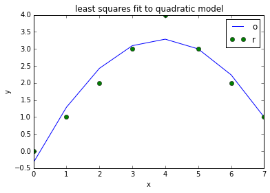

```python
import functools

A = numpy.array([0, 1, 2, 3, 4, 3, 2, 1])
B = numpy.array([0, 1, 2, 3, 4, 5, 6, 7])

def poly(x, a, b, c):
    return a + b*x + c*x*x

abc, cov = optimize.curve_fit(poly, B, A) # going to do the least squares fit like before

fixed = functools.partial(poly, a=abc[0], b=abc[1], c=abc[2]) # freeze the polynomial
fixed = numpy.vectorize(fixed) # create a vectorized version of the function

# the start of a plot
# pyplot is Matlab like, it is a state machine
plt.figure() # start a new plot
plt.xlabel('x') # labels
plt.ylabel('y')
plt.plot(B, fixed(B)) # the x and y values of the model
plt.legend('model')
plt.plot(B, A, 'o') # 'o' means plot it with circles
plt.legend('original')
plt.title('least squares fit to quadratic model') # a title
plt.show() # show it

# plt.savefig('foo.png') # write it to an image
```

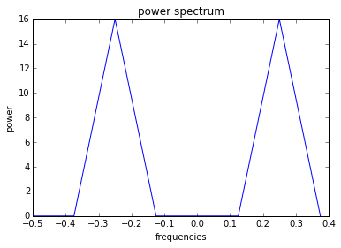

```python
from scipy import fftpack
from scipy import fft

A = numpy.array([0, 1, 0, -1, 0, 1, 0, -1])

f = numpy.abs(fftpack.fft(A)) ** 2 # power spectrum
q = fftpack.fftfreq(A.size, 1.0) # get the frequencies
i = numpy.argsort(q) # get the indices that would sort the frequencies

plt.figure() # plot it
plt.title('power spectrum')
plt.xlabel('frequencies')
plt.ylabel('power')
plt.plot(q[i], f[i])
plt.show()
```

```python
import numpy as np
import matplotlib.pyplot as plt

#create a numpy array
a = np.random.normal(0,0.1,10000)
plt.hist(a,64,normed = 1, facecolor = 'green', alpha=0.5)
plt.show()
```

[output not shown]

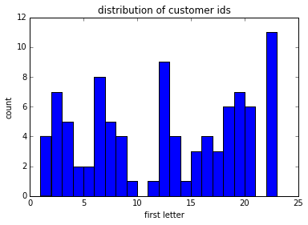

```
W
```

```python
# sqlite is awesome to store your data in
# stop using custom text files, and use sqlite

import sqlite3
conn = sqlite3.connect('northwind.db') # connect to the database
cursor = conn.cursor()

cursor.execute('select CustomerID from customers')
# convert the first letter of the customer id to a number
data = cursor.fetchall()
customers = [ord(i[0][0]) - ord('A') + 1 for i in data]
bins = numpy.max(customers) - numpy.min(customers)

# let's plot the distribution
plt.figure()
plt.title('distribution of customer ids')
plt.xlabel('first letter')
plt.ylabel('count')
plt.hist(customers, bins)
plt.show()

# what's the max letter?
counts = numpy.histogram(customers, bins)[0]
print(chr(numpy.argmax(counts) + numpy.min(customers) + ord('A')))
```

# Where to go from here?

- Lots of features I didn't cover in Matplotlib: [Matplotlib Gallery](http://matplotlib.org/gallery.html)
- Matplotlib can do 3D visualization
- More powerful 3D visualization is available through [VTK](http://vtk.org) and [ParaView](http://paraview.org) bindings
- Example of a really cool and sophisticated visualization and analysis toolchain, checkout [yt](http://yt-project.org/) for Cosmological and Astrophyics analysis
- To do web style graphics, try [Bokeh](http://bokeh.pydata.org/)
- You can even script [Blender](http://www.blender.org/documentation/blender_python_api_2_72_release/#blender-python-documentation) for modeling and rendering
- If you'd rather do it from scratch, there's [PyOpenGL](http://pyopengl.sourceforge.net/)
- Also, if you're interested, theres [PyGame](http://www.pygame.org/news.html) bindings to the SDL library
- For data sources, there's tons of bindings to SQL style databases, HDF5, NetCDF, etc. First, try using SQLite3. While it won't scale, it will certainly make smaller data sets managable
- For big data, cloud databases, etc. try [Blaze](http://blaze.pydata.org/docs/latest/index.html)
- For GUIs, try PyQt (there are other options as well)

## And the list goes on, and on, and on...

# Now go out and write some Python

- From my experience at the lab, there are so many problems that can be solved just with a "scripting" language
- Though, it's unfair to call Python scripting, as many applications are written in Python as the main language

## Too many problems are prematurely optimized

- For example, in visualization and analysis, a lot the bottleneck is in the I/O
- Then, Python will typically go almost as fast as C
- Faster turn around time in your research if you rapid prototype, and then find the bottlenecks
- But, Python won't solve all your problems, especially if you are CPU bound or memory-bandwidth bound